# VarCov Matrices for Random Effects

Author

Clay Ford

In this note I show how to suppress estimation of covariance random effects when estimating random effects for a categorical predictor.

The following data come from Ch 5 of *Linear Mixed Models* by West et al.

An experiment that examined nucleotide activation in 5 different rats. Each rat was subjected to two different treatments (basal vs carbachol) and then nucleotide activation was measured in 3 different brain regions. Therefore each rat has 6 different measures.

```r
library(lme4)
library(afex)
library(nlme)
ratbrain <- read.csv("ratbrain.csv")
head(ratbrain, n = 8)
```

```
   animal treatment region activate
1 R111097     basal    BST   366.19
2 R111097     basal     LS   199.31
3 R111097     basal    VDB   187.11
4 R111097 carbachol    BST   371.71
5 R111097 carbachol     LS   302.02
6 R111097 carbachol    VDB   449.70
7 R111397     basal    BST   375.58
8 R111397     basal     LS   204.85
```

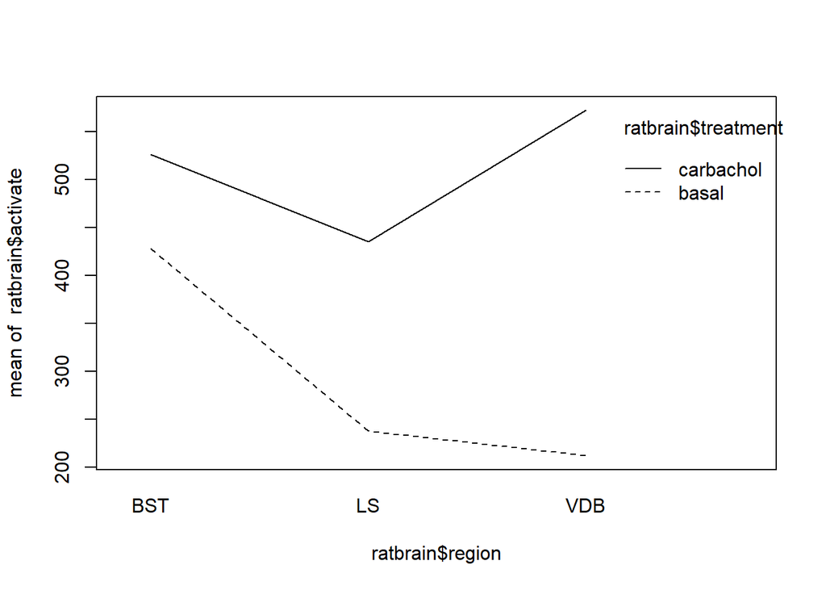

```r
interaction.plot(x.factor = ratbrain$region,
                 trace.factor = ratbrain$treatment,
                 response = ratbrain$activate)
```

Model `activate` as a function of region and treatment (and their interaction) with random effects on the intercept and region. Notice the singular fit message, This is due to the ill-conditioned random-effects covariance matrix, which suggests the model may be over-parameterized. Specifically we may not need to model covariance between the levels of the region random effects. The summary shows them all as -1 or 1.

```r
m1 <- lmer(activate ~ region * treatment + (region | animal),
            data = ratbrain)
```

```
boundary (singular) fit: see help('isSingular')
```

```r
summary(m1, corr = F)
```

```
Linear mixed model fit by REML. t-tests use Satterthwaite's method [
lmerModLmerTest]
Formula: activate ~ region * treatment + (region | animal)
   Data: ratbrain

REML criterion at convergence: 275.2

Scaled residuals:
     Min       1Q   Median       3Q      Max
-1.38732 -0.58863  0.08712  0.41762  1.56355

Random effects:
 Groups   Name        Variance Std.Dev. Corr
 animal   (Intercept) 5287.56  72.716
          regionLS      32.38   5.690   -1.00
          regionVDB     12.26   3.502   -1.00  1.00
 Residual             2443.21  49.429
Number of obs: 30, groups:  animal, 5

Fixed effects:
                             Estimate Std. Error       df t value Pr(>|t|)
(Intercept)                   428.506     39.321    5.694  10.898 5.00e-05 ***
regionLS                     -190.762     31.365   19.630  -6.082 6.56e-06 ***
regionVDB                    -216.212     31.301   19.855  -6.908 1.08e-06 ***
treatmentcarbachol             98.204     31.262   20.000   3.141  0.00514 **
regionLS:treatmentcarbachol    99.322     44.210   20.000   2.247  0.03612 *
regionVDB:treatmentcarbachol  261.822     44.210   20.000   5.922 8.60e-06 ***
---
Signif. codes:  0 '***' 0.001 '**' 0.01 '*' 0.05 '.' 0.1 ' ' 1
optimizer (nloptwrap) convergence code: 0 (OK)
boundary (singular) fit: see help('isSingular')
```

How can we fit a model without the covariance between random effects? Unfortunately, we can’t do that in {lme4}. However we can do so with the {afex} or {nlme} packages.

The {afex} package provides the `lmer_alt()` function that allows the use of two bars between region and animal (`region || animal`) to suppress estimation of random effect covariances (i.e., they are held constant at 0). However we still get warning about singularities.

```r
m2 <- lmer_alt(activate ~ region * treatment + (region || animal),
            data = ratbrain)
```

```
boundary (singular) fit: see help('isSingular')
```

```r
summary(m2, corr = F)
```

```
Linear mixed model fit by REML. t-tests use Satterthwaite's method [
lmerModLmerTest]
Formula: activate ~ region * treatment + (1 + re1.regionLS + re1.regionVDB ||
    animal)
   Data: data

REML criterion at convergence: 275.3

Scaled residuals:
    Min      1Q  Median      3Q     Max
-1.4643 -0.5762  0.0802  0.4072  1.5509

Random effects:
 Groups   Name          Variance Std.Dev.
 animal   (Intercept)   4850     69.64
 animal.1 re1.regionLS     0      0.00
 animal.2 re1.regionVDB    0      0.00
 Residual               2450     49.50
Number of obs: 30, groups:  animal, 5

Fixed effects:
                             Estimate Std. Error       df t value Pr(>|t|)
(Intercept)                   428.506     38.210    7.484  11.214 6.04e-06 ***
regionLS                     -190.762     31.307   20.000  -6.093 5.91e-06 ***
regionVDB                    -216.212     31.307   20.000  -6.906 1.04e-06 ***
treatmentcarbachol             98.204     31.307   20.000   3.137  0.00519 **
regionLS:treatmentcarbachol    99.322     44.275   20.000   2.243  0.03636 *
regionVDB:treatmentcarbachol  261.822     44.275   20.000   5.914 8.76e-06 ***
---
Signif. codes:  0 '***' 0.001 '**' 0.01 '*' 0.05 '.' 0.1 ' ' 1
optimizer (nloptwrap) convergence code: 0 (OK)
boundary (singular) fit: see help('isSingular')
```

In the {nlme} package we can use the `pdDiag()` to specify we want to fit a *diagonal* random effects matrix with covariances fixed at 0. Notice this requires a named list object, where the name is the grouping factor. This converges with no warning messages. This may be due to `lme()` using a different optimizer. It uses “BFGS” while `lmer()` uses “nloptwrap”.

```r
library(nlme)
m3 <- lme(activate ~ region * treatment,
          random = list(animal = pdDiag(~ region)),
          data = ratbrain)
summary(m3)
```

```
Linear mixed-effects model fit by REML
  Data: ratbrain
       AIC      BIC    logLik
  295.2822 307.0627 -137.6411

Random effects:
 Formula: ~region | animal
 Structure: Diagonal
        (Intercept)    regionLS   regionVDB Residual
StdDev:    69.64057 0.002818092 0.003204284 49.50045

Fixed effects:  activate ~ region * treatment
                                Value Std.Error DF   t-value p-value
(Intercept)                   428.506  38.21022 20 11.214434  0.0000
regionLS                     -190.762  31.30684 20 -6.093302  0.0000
regionVDB                    -216.212  31.30684 20 -6.906223  0.0000
treatmentcarbachol             98.204  31.30684 20  3.136823  0.0052
regionLS:treatmentcarbachol    99.322  44.27455 20  2.243320  0.0364
regionVDB:treatmentcarbachol  261.822  44.27455 20  5.913600  0.0000
 Correlation:
                             (Intr) regnLS rgnVDB trtmnt rgnLS:
regionLS                     -0.410
regionVDB                    -0.410  0.500
treatmentcarbachol           -0.410  0.500  0.500
regionLS:treatmentcarbachol   0.290 -0.707 -0.354 -0.707
regionVDB:treatmentcarbachol  0.290 -0.354 -0.707 -0.707  0.500

Standardized Within-Group Residuals:
        Min          Q1         Med          Q3         Max
-1.46425392 -0.57621824  0.08020305  0.40718429  1.55091561

Number of Observations: 30
Number of Groups: 5
```

### References

West, B., Welch, K., & Galecki, A. (2015) *Linear Mixed Models*. Chapman and Hall/CRC.